# Final project: Based on the coffee_survey data (tidytuesday)

Eszter Palócz

2024-12-16

# The data and hypothesis

The dataset used for this project is the Coffee Survey data from Tidy Tuesday (from 2024/05/14). The data was gained from the “Great American Coffee Taste Test”, which was a test on YouTube by James Hoffmann (world champion barista) and coffee company Cometeer. The test was conducted among American YouTube viewers who ordered coffees from Cometeer for the tasting.

In this project, I will explore the associations between the typical spendings on coffee in a month and age, gender, the number of children and employment status.

The simple model will have the outcome variable of total average monthly spending on coffee and 2 predictors:

- age
- gender

The complex model will have two additional predictors in addition to age and gender:

- employment status
- number of children

My hypothesis is that the complex model explains the outcome variable better, thus employment status (being employed) and the number of children (having more children) explains the outcome variable better.

## Setup

### Loading packages

```r
library(tidytuesdayR)
library(tidyverse)
library(dplyr)
library(knitr)
library(MASS)
library(brant)
library(car)
library(nnet)
```

### Reading the data

```r
# Reading the data
tuesdata <- tidytuesdayR::tt_load('2024-05-14')
```

```
## ---- Compiling #TidyTuesday Information for 2024-05-14 ----
## --- There is 1 file available ---
##
##
## ── Downloading files ───────────────────────────────────────────────────────────
##
##   1 of 1: "coffee_survey.csv"
```

```r
coffee_survey <- tuesdata$coffee_survey
```

### Checking the data

```r
# Checking the structure of the data
str(coffee_survey)
```

```
## spc_tbl_ [4,042 × 57] (S3: spec_tbl_df/tbl_df/tbl/data.frame)
##  $ submission_id               : chr [1:4042] "gMR29l" "BkPN0e" "W5G8jj" "4xWgGr" ...
##  $ age                         : chr [1:4042] "18-24 years old" "25-34 years old" "25-34 years old" "35-44 years old" ...
##  $ cups                        : chr [1:4042] NA NA NA NA ...
##  $ where_drink                 : chr [1:4042] NA NA NA NA ...
##  $ brew                        : chr [1:4042] NA "Pod/capsule machine (e.g. Keurig/Nespresso)" "Bean-to-cup machine" "Coffee brewing machine (e.g. Mr. Coffee)" ...
##  $ brew_other                  : chr [1:4042] NA NA NA NA ...
##  $ purchase                    : chr [1:4042] NA NA NA NA ...
##  $ purchase_other              : chr [1:4042] NA NA NA NA ...
##  $ favorite                    : chr [1:4042] "Regular drip coffee" "Iced coffee" "Regular drip coffee" "Iced coffee" ...
##  $ favorite_specify            : chr [1:4042] NA NA NA NA ...
##  $ additions                   : chr [1:4042] "No - just black" "Sugar or sweetener, No - just black" "No - just black" "No - just black, Cinnamon" ...
##  $ additions_other             : chr [1:4042] NA NA NA NA ...
##  $ dairy                       : chr [1:4042] NA NA NA NA ...
##  $ sweetener                   : chr [1:4042] NA NA NA NA ...
##  $ style                       : chr [1:4042] "Complex" "Light" "Complex" "Complex" ...
##  $ strength                    : chr [1:4042] NA NA NA NA ...
##  $ roast_level                 : chr [1:4042] NA NA NA NA ...
##  $ caffeine                    : chr [1:4042] NA NA NA NA ...
##  $ expertise                   : num [1:4042] NA NA NA NA NA NA NA NA NA NA ...
##  $ coffee_a_bitterness         : num [1:4042] NA NA NA NA NA NA NA NA 4 NA ...
##  $ coffee_a_acidity            : num [1:4042] NA NA NA NA NA NA NA NA 4 NA ...
##  $ coffee_a_personal_preference: num [1:4042] NA NA NA NA NA NA NA NA 4 NA ...
##  $ coffee_a_notes              : chr [1:4042] NA NA NA NA ...
##  $ coffee_b_bitterness         : num [1:4042] NA NA NA NA NA NA NA NA 4 NA ...
##  $ coffee_b_acidity            : num [1:4042] NA NA NA NA NA NA NA NA 4 NA ...
##  $ coffee_b_personal_preference: num [1:4042] NA NA NA NA NA NA NA NA 4 NA ...
##  $ coffee_b_notes              : chr [1:4042] NA NA NA NA ...
##  $ coffee_c_bitterness         : num [1:4042] NA NA NA NA NA NA NA NA 4 NA ...
##  $ coffee_c_acidity            : num [1:4042] NA NA NA NA NA NA NA NA 4 NA ...
##  $ coffee_c_personal_preference: num [1:4042] NA NA NA NA NA NA NA NA 4 NA ...
##  $ coffee_c_notes              : chr [1:4042] NA NA NA NA ...
##  $ coffee_d_bitterness         : num [1:4042] NA NA NA NA NA NA NA NA 4 NA ...
##  $ coffee_d_acidity            : num [1:4042] NA NA NA NA NA NA NA NA 4 NA ...
##  $ coffee_d_personal_preference: num [1:4042] NA NA NA NA NA NA NA NA 4 NA ...
##  $ coffee_d_notes              : chr [1:4042] NA NA NA NA ...
##  $ prefer_abc                  : chr [1:4042] NA NA NA NA ...
##  $ prefer_ad                   : chr [1:4042] NA NA NA NA ...
##  $ prefer_overall              : chr [1:4042] NA NA NA NA ...
##  $ wfh                         : chr [1:4042] NA NA NA NA ...
```

[output cut: 64 more lines]

```
##   ..   most_paid = col_character(),
##   ..   most_willing = col_character(),
##   ..   value_cafe = col_character(),
##   ..   spent_equipment = col_character(),
##   ..   value_equipment = col_character(),
##   ..   gender = col_character(),
##   ..   gender_specify = col_character(),
##   ..   education_level = col_character(),
##   ..   ethnicity_race = col_character(),
##   ..   ethnicity_race_specify = col_character(),
##   ..   employment_status = col_character(),
##   ..   number_children = col_character(),
##   ..   political_affiliation = col_character()
##   .. )
##  - attr(*, "problems")=<externalptr>
```

```r
# Checking the first and last rows of the data
head(coffee_survey)
```

```
## # A tibble: 6 × 57
##   submission_id age   cups  where_drink brew  brew_other purchase purchase_other
##   <chr>         <chr> <chr> <chr>       <chr> <chr>      <chr>    <chr>
## 1 gMR29l        18-2… <NA>  <NA>        <NA>  <NA>       <NA>     <NA>
## 2 BkPN0e        25-3… <NA>  <NA>        Pod/… <NA>       <NA>     <NA>
## 3 W5G8jj        25-3… <NA>  <NA>        Bean… <NA>       <NA>     <NA>
## 4 4xWgGr        35-4… <NA>  <NA>        Coff… <NA>       <NA>     <NA>
## 5 QD27Q8        25-3… <NA>  <NA>        Pour… <NA>       <NA>     <NA>
## 6 V0LPeM        55-6… <NA>  <NA>        Pod/… <NA>       <NA>     <NA>
## # ℹ 49 more variables: favorite <chr>, favorite_specify <chr>, additions <chr>,
## #   additions_other <chr>, dairy <chr>, sweetener <chr>, style <chr>,
## #   strength <chr>, roast_level <chr>, caffeine <chr>, expertise <dbl>,
## #   coffee_a_bitterness <dbl>, coffee_a_acidity <dbl>,
## #   coffee_a_personal_preference <dbl>, coffee_a_notes <chr>,
## #   coffee_b_bitterness <dbl>, coffee_b_acidity <dbl>,
## #   coffee_b_personal_preference <dbl>, coffee_b_notes <chr>, …
```

```r
tail(coffee_survey)
```

```
## # A tibble: 6 × 57
##   submission_id age   cups  where_drink brew  brew_other purchase purchase_other
##   <chr>         <chr> <chr> <chr>       <chr> <chr>      <chr>    <chr>
## 1 42EpEY        25-3… More… At home     Espr… <NA>       <NA>     <NA>
## 2 PA44VP        >65 … 2     At home     Coff… <NA>       <NA>     <NA>
## 3 vNgpPD        >65 … 2     At home     Coff… <NA>       <NA>     <NA>
## 4 g5ggRM        18-2… 1     At a cafe,… Espr… Aeropress  Nationa… <NA>
## 5 rlgbDN        25-3… 2     At home     Pour… <NA>       <NA>     <NA>
## 6 0EGYe9        25-3… 1     At home     Pour… Aeropress  <NA>     <NA>
## # ℹ 49 more variables: favorite <chr>, favorite_specify <chr>, additions <chr>,
## #   additions_other <chr>, dairy <chr>, sweetener <chr>, style <chr>,
## #   strength <chr>, roast_level <chr>, caffeine <chr>, expertise <dbl>,
## #   coffee_a_bitterness <dbl>, coffee_a_acidity <dbl>,
## #   coffee_a_personal_preference <dbl>, coffee_a_notes <chr>,
## #   coffee_b_bitterness <dbl>, coffee_b_acidity <dbl>,
## #   coffee_b_personal_preference <dbl>, coffee_b_notes <chr>, …
```

```r
# Checking missing values
## Checking for missing values in the whole dataset and the columns
sum(is.na(coffee_survey))
```

```
## [1] 56764
```

```r
colSums(is.na(coffee_survey))
```

```
##                submission_id                          age
##                            0                           31
##                         cups                  where_drink
##                           93                           70
##                         brew                   brew_other
##                          385                         3364
##                     purchase               purchase_other
##                         3332                         4011
##                     favorite             favorite_specify
##                           62                         3926
##                    additions              additions_other
##                           83                         3994
##                        dairy                    sweetener
##                         2356                         3530
##                        style                     strength
##                           84                          126
##                  roast_level                     caffeine
##                          102                          125
##                    expertise          coffee_a_bitterness
##                          104                          244
##             coffee_a_acidity coffee_a_personal_preference
##                          263                          253
##               coffee_a_notes          coffee_b_bitterness
##                         1464                          262
##             coffee_b_acidity coffee_b_personal_preference
##                          275                          269
##               coffee_b_notes          coffee_c_bitterness
##                         1586                          278
##             coffee_c_acidity coffee_c_personal_preference
##                          291                          276
##               coffee_c_notes          coffee_d_bitterness
##                         1659                          275
##             coffee_d_acidity coffee_d_personal_preference
##                          277                          278
##               coffee_d_notes                   prefer_abc
##                         1454                          270
##                    prefer_ad               prefer_overall
##                          281                          272
##                          wfh                  total_spend
##                          518                          531
##                    why_drink              why_drink_other
##                          474                         3875
##                        taste                  know_source
##                          479                          483
##                    most_paid                 most_willing
##                          515                          532
##                   value_cafe              spent_equipment
##                          542                          536
##              value_equipment                       gender
##                          548                          519
##               gender_specify              education_level
##                         4030                          604
##               ethnicity_race       ethnicity_race_specify
##                          624                         3937
##            employment_status              number_children
##                          623                          636
##        political_affiliation
##                          753
```

```r
## Checking the percentage of missing values per variable that is relevant for the research question
mean(is.na(coffee_survey$total_spend)) * 100
```

```
## [1] 13.13706
```

```r
mean(is.na(coffee_survey$age)) * 100
```

```
## [1] 0.7669471
```

```r
mean(is.na(coffee_survey$gender)) * 100
```

```
## [1] 12.84018
```

```r
mean(is.na(coffee_survey$employment_status)) * 100
```

```
## [1] 15.41316
```

```r
mean(is.na(coffee_survey$number_children)) * 100
```

```
## [1] 15.73478
```

There are between 0.7% (age) to 16% (number of children) of missing variables.

## Manipulating the data and variables

```r
# Creating a subset of the data for the analysis
coffee_subset <- coffee_survey %>%
  dplyr::select(total_spend, cups, age, gender, education_level, employment_status, number_children)

## Checking the coffee_subset data
head(coffee_subset)
```

```
## # A tibble: 6 × 7
##   total_spend cups  age             gender education_level employment_status
##   <chr>       <chr> <chr>           <chr>  <chr>           <chr>
## 1 <NA>        <NA>  18-24 years old <NA>   <NA>            <NA>
## 2 <NA>        <NA>  25-34 years old <NA>   <NA>            <NA>
## 3 <NA>        <NA>  25-34 years old <NA>   <NA>            <NA>
## 4 <NA>        <NA>  35-44 years old <NA>   <NA>            <NA>
## 5 <NA>        <NA>  25-34 years old <NA>   <NA>            <NA>
## 6 <NA>        <NA>  55-64 years old <NA>   <NA>            <NA>
## # ℹ 1 more variable: number_children <chr>
```

```r
str(coffee_subset)
```

```
## tibble [4,042 × 7] (S3: tbl_df/tbl/data.frame)
##  $ total_spend      : chr [1:4042] NA NA NA NA ...
##  $ cups             : chr [1:4042] NA NA NA NA ...
##  $ age              : chr [1:4042] "18-24 years old" "25-34 years old" "25-34 years old" "35-44 years old" ...
##  $ gender           : chr [1:4042] NA NA NA NA ...
##  $ education_level  : chr [1:4042] NA NA NA NA ...
##  $ employment_status: chr [1:4042] NA NA NA NA ...
##  $ number_children  : chr [1:4042] NA NA NA NA ...
```

```r
# Manipulating the data and variables
## Excluding missing data
coffee_subset_clean <- coffee_subset %>%
  filter(!if_any(c(total_spend, cups, age, gender, employment_status, number_children), is.na))

## Checking the new dataset and variables
head(coffee_subset_clean)
```

```
## # A tibble: 6 × 7
##   total_spend cups        age           gender education_level employment_status
##   <chr>       <chr>       <chr>         <chr>  <chr>           <chr>
## 1 >$100       3           <18 years old Other… Bachelor's deg… Employed full-ti…
## 2 $40-$60     1           25-34 years … Female Bachelor's deg… Employed full-ti…
## 3 $20-$40     2           45-54 years … Male   Master's degree Employed full-ti…
## 4 $40-$60     2           25-34 years … Male   Master's degree Unemployed
## 5 $20-$40     1           35-44 years … Male   Bachelor's deg… Employed full-ti…
## 6 $40-$60     More than 4 45-54 years … Male   Bachelor's deg… Employed full-ti…
## # ℹ 1 more variable: number_children <chr>
```

```r
## Manipulating variables for the analysis (regrouping and creating factors)
coffee_subset_filtered <- coffee_subset_clean %>%

  ## 1. Dependent variable: total_spend (total amount spent on coffee on average per month)
  # Creating new groups for total_spend: $0-$40, $40-$80, $80+ and transforming to factor
  mutate(totalspending_new = case_when(
    total_spend %in% c("<$20", "$20-$40") ~ "$0-$40",
    total_spend %in% c("$40-$60", "$60-$80") ~ "$40-$80",
    total_spend %in% c("$80-$100", ">$100") ~ "$80+",
    TRUE ~ as.character(total_spend, levels = "$0-$40", "$40-$80", "$80+")
  )) %>%
  mutate(totalspending_new = factor(totalspending_new, levels = c("$0-$40", "$40-$80", "$80+"))) %>%

  ## Predictor variable 1. Gender
  # Excluding values with a very low count and transforming to factor
  filter(!gender %in% c("Other (please specify)", "Prefer not to say")) %>%
  mutate(gender = factor(gender, levels = c("Male", "Female", "Non-binary"))) %>%

  ## Predictor variable 2. Age
  # Creating new groups for age variable: <18-24 years old, 25-34 years old, 35-44 years old, 45+ years old and transforming to factor
  mutate(age_newgroup = case_when(
    age %in% c("<18 years old", "18-24 years old") ~ "<18-24 years old",
    age %in% c("45-54 years old", "55-64 years old", ">65 years old") ~ "45+ years old",
    TRUE ~ as.character(age)
  )) %>%
  mutate(age_newgroup = factor(age_newgroup, levels = c(levels = "<18-24 years old", "25-34 years old", "35-44 years old", "45+ years old"))) %>%

  ## Predictor variable 3. Employment status
  # Creating new groups for Employment status: Employed, Not employed and transforming to factor
  mutate(employment_new = case_when(
    employment_status %in% c("Employed full-time", "Employed part-time") ~ "Employed",
    employment_status %in% c("Homemaker", "Retired", "Student", "Unemployed") ~ "Not employed",
    TRUE ~ as.character(employment_status)
  )) %>%
  mutate(employment_new = factor(employment_new, levels = c("Employed", "Not employed"))) %>%

  ## Predictor variable 4. Number of children
  # Creating new groups for Number of children: None, 1-2, 3 or more and transforming to factor
  mutate(child_new = case_when(
    number_children %in% c("1", "2") ~ "1-2",
    number_children %in% c("3", "More than 3") ~ "3 or more",
    TRUE ~ as.character(number_children)
  )) %>%
  mutate(child_new = factor(child_new, levels = c("None", "1-2", "3 or more"))) %>%

## Cups - new categories
  mutate(cups_new = case_when(
    cups %in% c("1", "Less than 1") ~ "1 or less",
    cups %in% c("4", "More than 4") ~ "4 or more",
    TRUE ~ as.character(cups)
  )) %>%
  mutate(cups_new = factor(cups_new, levels = c("1 or less", "2", "3", "4 or more")))

## Checking levels of the new variables to ensure they were created successfully
levels(coffee_subset_filtered$totalspending_new)
```

```
## [1] "$0-$40"  "$40-$80" "$80+"
```

```r
levels(coffee_subset_filtered$gender)
```

```
## [1] "Male"       "Female"     "Non-binary"
```

```r
levels(coffee_subset_filtered$age_newgroup)
```

```
## [1] "<18-24 years old" "25-34 years old"  "35-44 years old"  "45+ years old"
```

```r
levels(coffee_subset_filtered$employment_new)
```

```
## [1] "Employed"     "Not employed"
```

```r
levels(coffee_subset_filtered$child_new)
```

```
## [1] "None"      "1-2"       "3 or more"
```

```r
levels(coffee_subset_filtered$cups_new)
```

```
## [1] "1 or less" "2"         "3"         "4 or more"
```

The levels were created successfully: Total spending (3 levels: “$0-$40” “$40-$80” “$80+” Gender (3 levels): “Female” “Male” “Non-binary” Age (4 levels): “<18-24 years old” “25-34 years old” “35-44 years old” “45+ years old”  
Employment status (2 levels): “Employed” “Not employed” Number of children (3 levels): “1-2” 3 or more” “None”  
Cups (4 levels): “1 or less”, “2”, “3”, “4 or more”

### Calculating proportions

```r
## Gender proportions
gender_counts <- table(coffee_subset_filtered$gender)
gender_proportions <- prop.table(gender_counts) * 100
gender_proportions_rounded <- round(gender_proportions, 0)
kable(gender_proportions_rounded)
```

| Var1 | Freq |
| --- | --- |
| Male | 73 |
| Female | 24 |
| Non-binary | 3 |

```r
## Age proportions
age_counts <- table(coffee_subset_filtered$age_newgroup)
age_proportions <- prop.table(age_counts) * 100
age_proportions_rounded <- round(age_proportions, 0)
kable(age_proportions_rounded)
```

| Var1 | Freq |
| --- | --- |
| <18-24 years old | 11 |
| 25-34 years old | 52 |
| 35-44 years old | 24 |
| 45+ years old | 13 |

```r
## Employment
emp_counts <- table(coffee_subset_filtered$employment_new)
emp_proportions <- prop.table(emp_counts) * 100
emp_proportions_rounded <- round(emp_proportions, 0)
kable(emp_proportions_rounded)
```

| Var1 | Freq |
| --- | --- |
| Employed | 85 |
| Not employed | 15 |

```r
## Number of children
child_counts <- table(coffee_subset_filtered$child_new)
child_proportions <- prop.table(child_counts) * 100
child_proportions_rounded <- round(child_proportions, )
kable(child_proportions_rounded)
```

| Var1 | Freq |
| --- | --- |
| None | 75 |
| 1-2 | 21 |
| 3 or more | 4 |

# Creating visualisations

### Gender and total spending on coffee

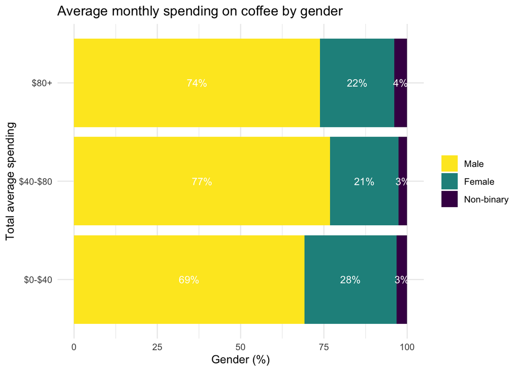

```r
## 1. Gender by total spending on coffee
# Calculating proportions for each gender category within each spending category
gender_spending_proportions <- coffee_subset_filtered %>%
  group_by(totalspending_new, gender) %>%
  summarise(count = n(), .groups = "drop") %>%
  group_by(totalspending_new) %>%
  mutate(proportion = (count / sum(count)) * 100) %>%
  mutate(gender = factor(gender, levels = rev(c("Male", "Female", "Non-binary"))))

# Bar chart Gender x total spending
library(ggplot2)
library(viridis)
ggplot(gender_spending_proportions, aes(x = totalspending_new, y = proportion, fill = gender)) +
  geom_bar(stat = "identity", position = "stack") +
  geom_text(aes(label = ifelse(proportion > 0, paste0(round(proportion), "%"), "")),
            position = position_stack(vjust = 0.5),
            size = 3.5, color = "white") +
  scale_fill_viridis(
    breaks = c("Male", "Female", "Non-binary"),
    discrete = TRUE) +
  coord_flip() +
  theme_minimal() +
  guides(fill = guide_legend(title = NULL)) +
  labs(
    title = "Average monthly spending on coffee by gender",
    x = "Total average spending",
    y = "Gender (%)",
    fill = "Gender"
  )
```

The first bar chart shows that there is a bit of a higher proportion of women (28%) in the lowest spending group ($0-$40) compared to the other two spending groups that are 21% ($40-$80) and 22% ($80+).

### Age and total spending on coffee

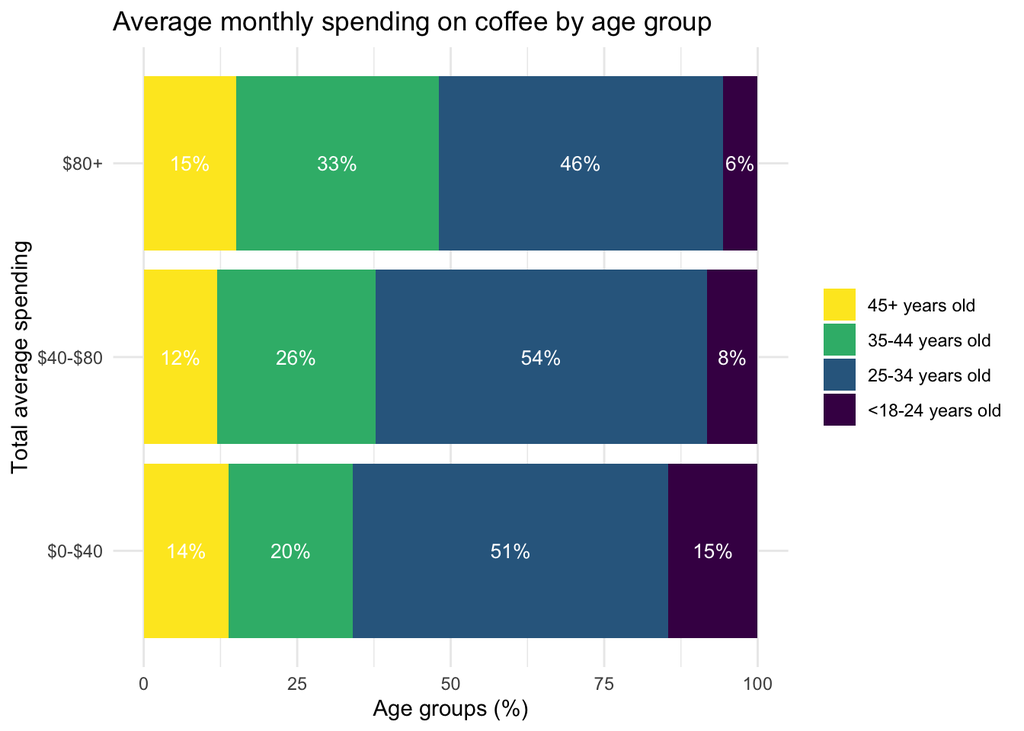

```r
## 2. Age and total spending on coffee
# Calculating proportions for each age group within each spending category
age_spending_proportions <- coffee_subset_filtered %>%
  group_by(totalspending_new, age_newgroup) %>%
  summarise(count = n(), .groups = "drop") %>%
  group_by(totalspending_new) %>%
  mutate(proportion = (count / sum(count)) * 100)

# Bar chart Age x Total spending
ggplot(age_spending_proportions, aes(x = totalspending_new, y = proportion, fill = age_newgroup)) +
  geom_bar(stat = "identity", position = "stack") +
  geom_text(aes(label = ifelse(proportion > 0, paste0(round(proportion), "%"), "")),
            position = position_stack(vjust = 0.5),
            size = 3.5, color = "white") +
  coord_flip() +
  theme_minimal() +
  scale_fill_viridis(
    breaks = c("45+ years old", "35-44 years old", "25-34 years old", "<18-24 years old"),
    discrete = TRUE) +
  guides(fill = guide_legend(title = NULL)) +
  labs(
    title = "Average monthly spending on coffee by age group",
    x = "Total average spending",
    y = "Age groups (%)"
  )
```

In the second bar chart, it is visible that the biggest age group in the data is 25-34 years olds and most of this age group spends between $0-$40 and $40-$80 a month on coffee. Older age groups are slightly more represented in the $80 spending group - 15% for 45+ year olds and 33% for 35-44 year olds.

### Employment and spending on coffee

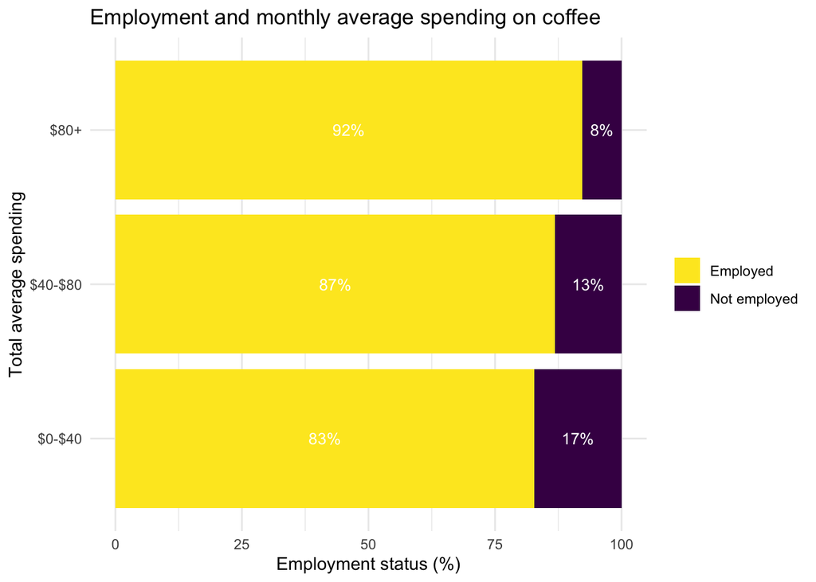

```r
## 3. Employment
# Calculating proportions for employment category within each spending category
emp_spending_proportions <- coffee_subset_filtered %>%
  group_by(totalspending_new, employment_new) %>%
  summarise(count = n(), .groups = "drop") %>%
  group_by(totalspending_new) %>%
  mutate(proportion = (count / sum(count)) * 100) %>%
  mutate(employment_new = factor(employment_new, levels = rev(c("Employed", "Not employed"))))

# Bar chart for employment x total spending
ggplot(emp_spending_proportions, aes(x = totalspending_new, y = proportion, fill = employment_new)) +
  geom_bar(stat = "identity", position = "stack") +
  geom_text(aes(label = ifelse(proportion > 0, paste0(round(proportion), "%"), "")),
            position = position_stack(vjust = 0.5),
            size = 3.5, color = "white") +
  coord_flip() +
  theme_minimal() +
  scale_fill_viridis(
    breaks = c("Employed", "Not employed"),
    discrete = TRUE) +
  guides(fill = guide_legend(title = NULL)) +
  labs(
    title = "Employment and monthly average spending on coffee",
    x = "Total average spending",
    y = "Employment status (%)"
  )
```

This bar chart shows that those that are unemployed are more represented in the lowest spending group of 0 to 40 US dollars per month with 17% as opposed to 8% in the highest spending group of 80+ US dollars.

### Number of children and spending on coffee

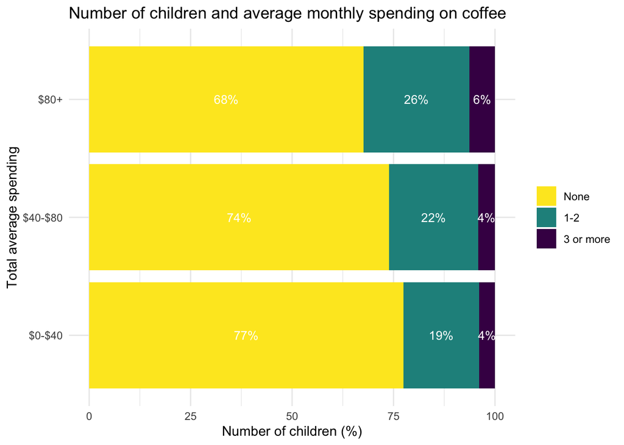

```r
## 4. Number of children
# Calculating proportions for the number of children within each spending category
child_spending_proportions <- coffee_subset_filtered %>%
  group_by(totalspending_new, child_new) %>%
  summarise(count = n(), .groups = "drop") %>%
  group_by(totalspending_new) %>%
  mutate(proportion = (count / sum(count)) * 100) %>%
  mutate(child_new = factor(child_new, levels = rev(c("None", "1-2", "3 or more"))))

# Bar chart for number of children x total spending
ggplot(child_spending_proportions, aes(x = totalspending_new, y = proportion, fill = child_new)) +
  geom_bar(stat = "identity", position = "stack") +
  geom_text(aes(label = ifelse(proportion > 0, paste0(round(proportion), "%"), "")),
            position = position_stack(vjust = 0.5),
            size = 3.5, color = "white") +
  coord_flip() +
  theme_minimal() +
  scale_fill_viridis(
    breaks = c("None", "1-2", "3 or more"),
    discrete = TRUE) +
  guides(fill = guide_legend(title = NULL)) +
  labs(
    title = "Number of children and average monthly spending on coffee",
    x = "Total average spending",
    y = "Number of children (%)"
  )
```

Based on this bar chart, it seems that people who have children (1, 2 or 3 or more children) are more represented in the highest spending group of 80+ US dollars (26% for 1 or 2 children and 6% for 3 or more children), than the lowest spending group (19% for 1-2 children and 4% for 3 or more children).

### Cups of coffee per day and number of children

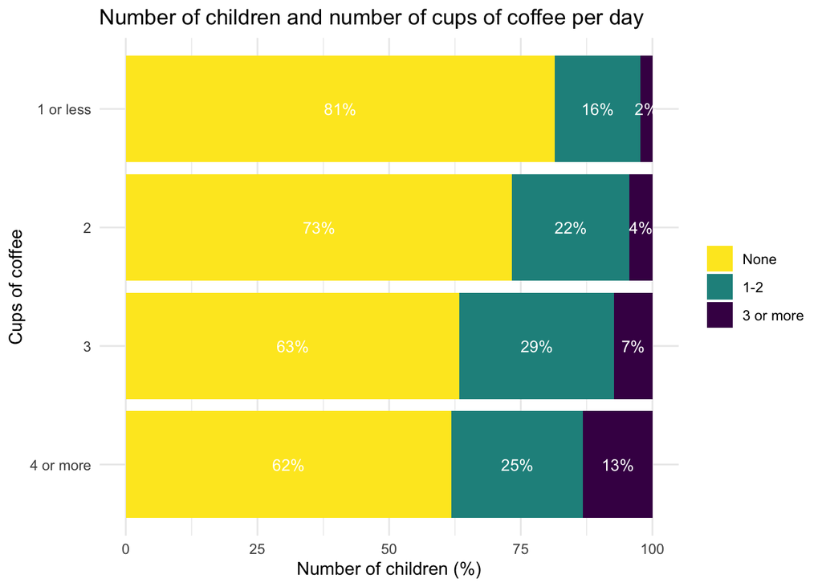

```r
## Another interesting visualisation: cups of coffee and children
# In this visualisation I will explore the trends of drinking coffee by the number of children

## Creating a visualisation to see the trend in the number of cups of coffee and having children
# Calculating proportions
cups_proportions <- coffee_subset_filtered %>%
  group_by(cups_new, child_new) %>%
  summarise(count = n(), .groups = "drop") %>%
  group_by(cups_new) %>%
  mutate(proportion = (count / sum(count)) * 100)

# Changing the order of categories for better visibility
cups_proportions <- cups_proportions %>%
  mutate(cups_new = factor(cups_new, levels = rev(c("1 or less", "2", "3", "4 or more"))))

cups_proportions <- cups_proportions %>%
  mutate(child_new = factor(child_new, levels = rev(c("None", "1-2", "3 or more"))))

# Creating the bar chart
ggplot(cups_proportions, aes(x = cups_new, y = proportion, fill = child_new)) +
  geom_bar(stat = "identity", position = "stack") +
  geom_text(aes(label = ifelse(proportion > 0, paste0(round(proportion), "%"), "")),
            position = position_stack(vjust = 0.5),
            size = 3.5, color = "white") +
  coord_flip() +
  theme_minimal() +
  scale_fill_viridis(
    breaks = c("None", "1-2", "3 or more"),
    discrete = TRUE) +
  guides(fill = guide_legend(title = NULL)) +
  labs(
    title = "Number of children and number of cups of coffee per day",
    x = "Cups of coffee",
    y = "Number of children (%)"
  )
```

The bar plot shows a trend of people drinking more cups of coffee per day if they have children. A significant majority (81%) of people consuming 1 or less cup of coffee per day have no children, while this decreases to 62% in the group that drinks 4 or more cups a day and the percentage increases for people who have children. Thus, the number of cups of coffee increases as the number of children increases, suggesting there may be a link between the demands of being a parent and coffee consumption.

# Model diagnostics

```r
## Building and fitting the complex model: ordinal logistic regression where the outcome is total spending and the predictors are age, gender, educational level, employment, number of children

# Ensuring 'total_spending' is an ordered factor
coffee_subset_filtered$totalspending_new <- factor(coffee_subset_filtered$totalspending_new,
                                 levels = c("$0-$40", "$40-$80", "$80+"),
                                 ordered = TRUE)

# Fitting the model
ordinal_model <- polr(totalspending_new ~ age_newgroup + gender + employment_new + child_new, data = coffee_subset_filtered, Hess = TRUE)

# Summary of the model
summary(ordinal_model)
```

```
## Call:
## polr(formula = totalspending_new ~ age_newgroup + gender + employment_new +
##     child_new, data = coffee_subset_filtered, Hess = TRUE)
##
## Coefficients:
##                                Value Std. Error t value
## age_newgroup25-34 years old  0.56942    0.12108   4.703
## age_newgroup35-44 years old  0.82269    0.13587   6.055
## age_newgroup45+ years old    0.45214    0.15745   2.872
## genderFemale                -0.32691    0.08122  -4.025
## genderNon-binary            -0.03997    0.20286  -0.197
## employment_newNot employed  -0.25461    0.10157  -2.507
## child_new1-2                 0.18934    0.09182   2.062
## child_new3 or more           0.25952    0.17990   1.443
##
## Intercepts:
##                Value   Std. Error t value
## $0-$40|$40-$80  0.4386  0.1146     3.8270
## $40-$80|$80+    2.7162  0.1256    21.6280
##
## Residual Deviance: 6181.007
## AIC: 6201.007
```

## Checking assumptions

### Proportional Odds Assumption

```r
# Performing Brant test
brant_test <- brant(ordinal_model)
```

```
## ------------------------------------------------------------
## Test for         X2  df  probability
## ------------------------------------------------------------
## Omnibus              18.43   8   0.02
## age_newgroup25-34 years old  0.64    1   0.42
## age_newgroup35-44 years old  0   1   0.97
## age_newgroup45+ years old    0.49    1   0.48
## genderFemale         5.02    1   0.03
## genderNon-binary     4.02    1   0.04
## employment_newNot employed   4.61    1   0.03
## child_new1-2         0.06    1   0.81
## child_new3 or more       0.37    1   0.54
## ------------------------------------------------------------
##
## H0: Parallel Regression Assumption holds
```

```r
kable(brant_test)
```

|  | X2 | df | probability |
| --- | --- | --- | --- |
| Omnibus | 18.4305311 | 8 | 0.0182205 |
| age_newgroup25-34 years old | 0.6413168 | 1 | 0.4232344 |
| age_newgroup35-44 years old | 0.0010383 | 1 | 0.9742939 |
| age_newgroup45+ years old | 0.4886829 | 1 | 0.4845154 |
| genderFemale | 5.0157319 | 1 | 0.0251180 |
| genderNon-binary | 4.0247059 | 1 | 0.0448384 |
| employment_newNot employed | 4.6066666 | 1 | 0.0318479 |
| child_new1-2 | 0.0583496 | 1 | 0.8091238 |
| child_new3 or more | 0.3723244 | 1 | 0.5417400 |

Based on the Brant test, the assumption is not met.

### Next assumption: Multicollinearity

```r
# Checking multicollinearity (GVIF)
gvif_values_ordinal <- vif(ordinal_model)
kable(gvif_values_ordinal)
```

|  | GVIF | Df | GVIF^(1/(2*Df)) |
| --- | --- | --- | --- |
| age_newgroup | 1.442229 | 3 | 1.062933 |
| gender | 1.031040 | 2 | 1.007671 |
| employment_new | 1.084994 | 1 | 1.041630 |
| child_new | 1.340422 | 2 | 1.075995 |

There is no issue with multicollinearity in the model, since all values are within the acceptable limit of < 2.

Based on the results of the Brant test, the assumption of proportional odds is violated. Therefore, I will check if multinomial logistic regression model would be better for this model, since it is more flexible. The disadvantage of this model is that ordering of the outcome variable (total spending - $0-40, $40-$80, $80+) will not be considered.

## Multinomial regression model (complex model)

```r
# For this model, the dependent variable does not have to be ordered
coffee_subset_filtered$totalspending_new <- factor(coffee_subset_filtered$totalspending_new,
                                 levels = c("$0-$40", "$40-$80", "$80+"),
                                 ordered = FALSE)

# Fitting multinomial logistic regression model
multinom_model <- multinom(totalspending_new ~ age_newgroup + gender + employment_new + child_new, data = coffee_subset_filtered)
# Viewing the model summary
summary(multinom_model)
```

```
## Call:
## multinom(formula = totalspending_new ~ age_newgroup + gender +
##     employment_new + child_new, data = coffee_subset_filtered)
##
## Coefficients:
##         (Intercept) age_newgroup25-34 years old age_newgroup35-44 years old
## $40-$80  -0.6244599                   0.6023585                   0.7429731
## $80+     -2.2644105                   0.6457523                   1.1334622
##         age_newgroup45+ years old genderFemale genderNon-binary
## $40-$80                 0.3495890   -0.4047540       -0.2894580
## $80+                    0.7459178   -0.2474284        0.3060881
##         employment_newNot employed child_new1-2 child_new3 or more
## $40-$80                 -0.1028685    0.1554468          0.1542891
## $80+                    -0.7025161    0.2978351          0.4646066
##
## Std. Errors:
##         (Intercept) age_newgroup25-34 years old age_newgroup35-44 years old
## $40-$80   0.1228008                   0.1301205                   0.1477616
## $80+      0.2469971                   0.2595205                   0.2754917
##         age_newgroup45+ years old genderFemale genderNon-binary
## $40-$80                 0.1708661   0.08889845        0.2260437
## $80+                    0.3087606   0.14649394        0.3242102
##         employment_newNot employed child_new1-2 child_new3 or more
## $40-$80                  0.1095782    0.1025509          0.2024993
## $80+                     0.2219177    0.1575888          0.2843705
##
## Residual Deviance: 6162.742
## AIC: 6198.742
```

```r
# Comparing the goodness of fit of the two models
kable(AIC(ordinal_model, multinom_model))
```

|  | df | AIC |
| --- | --- | --- |
| ordinal_model | 10 | 6201.007 |
| multinom_model | 18 | 6198.742 |

```r
kable(BIC(ordinal_model, multinom_model))
```

|  | df | BIC |
| --- | --- | --- |
| ordinal_model | 10 | 6262.066 |
| multinom_model | 18 | 6308.649 |

### Checking assumptions for the multinomial logistic regression model

Based on looking at the dataset, there might be a slight issue with the outcome variable, because it is not clear whether the categories overlap or not between for example $0-40 and $40-$60. However, for the purpose of this project, I will assume that the categories do not overlap and the categories are mutually exclusive and exhaustive.

In addition, since there are no continuous variables, the assumptions related to continuous variables will be skipped (linearity, outliers).

```r
# Checking multicollinearity
gvif_values_complex <- vif(multinom_model)
kable(gvif_values_complex)
```

|  | GVIF | Df | GVIF^(1/(2*Df)) |
| --- | --- | --- | --- |
| age_newgroup | 18.739301 | 3 | 1.629767 |
| gender | 1.628895 | 2 | 1.129726 |
| employment_new | 1.328764 | 1 | 1.152720 |
| child_new | 2.285068 | 2 | 1.229489 |

## Simple model: total spending ~ age, gender

```r
# Building the model
simple_model <- multinom(totalspending_new ~ age_newgroup + gender, data = coffee_subset_filtered)
# Checking the model summary
summary(simple_model)
```

```
## Call:
## multinom(formula = totalspending_new ~ age_newgroup + gender,
##     data = coffee_subset_filtered)
##
## Coefficients:
##         (Intercept) age_newgroup25-34 years old age_newgroup35-44 years old
## $40-$80  -0.6595147                   0.6492765                   0.8337985
## $80+     -2.4702853                   0.8510110                   1.4474630
##         age_newgroup45+ years old genderFemale genderNon-binary
## $40-$80                 0.4685833   -0.4177615       -0.3136687
## $80+                    1.0751057   -0.3171700        0.2270820
##
## Std. Errors:
##         (Intercept) age_newgroup25-34 years old age_newgroup35-44 years old
## $40-$80   0.1163152                   0.1259144                   0.1385716
## $80+      0.2404560                   0.2543861                   0.2630277
##         age_newgroup45+ years old genderFemale genderNon-binary
## $40-$80                 0.1554111   0.08817485        0.2255984
## $80+                    0.2864076   0.14506683        0.3225199
##
## Residual Deviance: 6179.577
## AIC: 6203.577
```

### Checking assumptions for the simple model

(The above description about assumptions also applies for the simple model.)

```r
# Checking multicollinearity
gvif_values_simple <- vif(simple_model)
kable(gvif_values_simple)
```

|  | GVIF | Df | GVIF^(1/(2*Df)) |
| --- | --- | --- | --- |
| age_newgroup | 13.095157 | 3 | 1.535271 |
| gender | 1.597755 | 2 | 1.124288 |

# Comparing the simple and complex models

```r
## Likelihood ratio test
kable(anova(multinom_model, simple_model, test = "Chisq"))
```

| Model | Resid. df | Resid. Dev | Test | Df | LR stat. | Pr(Chi) |
| --- | --- | --- | --- | --- | --- | --- |
| age_newgroup + gender | 6616 | 6179.577 |  | NA | NA | NA |
| age_newgroup + gender + employment_new + child_new | 6610 | 6162.742 | 1 vs 2 | 6 | 16.83521 | 0.0099083 |

```r
## Model summary comparison
summary(multinom_model)
```

```
## Call:
## multinom(formula = totalspending_new ~ age_newgroup + gender +
##     employment_new + child_new, data = coffee_subset_filtered)
##
## Coefficients:
##         (Intercept) age_newgroup25-34 years old age_newgroup35-44 years old
## $40-$80  -0.6244599                   0.6023585                   0.7429731
## $80+     -2.2644105                   0.6457523                   1.1334622
##         age_newgroup45+ years old genderFemale genderNon-binary
## $40-$80                 0.3495890   -0.4047540       -0.2894580
## $80+                    0.7459178   -0.2474284        0.3060881
##         employment_newNot employed child_new1-2 child_new3 or more
## $40-$80                 -0.1028685    0.1554468          0.1542891
## $80+                    -0.7025161    0.2978351          0.4646066
##
## Std. Errors:
##         (Intercept) age_newgroup25-34 years old age_newgroup35-44 years old
## $40-$80   0.1228008                   0.1301205                   0.1477616
## $80+      0.2469971                   0.2595205                   0.2754917
##         age_newgroup45+ years old genderFemale genderNon-binary
## $40-$80                 0.1708661   0.08889845        0.2260437
## $80+                    0.3087606   0.14649394        0.3242102
##         employment_newNot employed child_new1-2 child_new3 or more
## $40-$80                  0.1095782    0.1025509          0.2024993
## $80+                     0.2219177    0.1575888          0.2843705
##
## Residual Deviance: 6162.742
## AIC: 6198.742
```

```r
summary(simple_model)
```

```
## Call:
## multinom(formula = totalspending_new ~ age_newgroup + gender,
##     data = coffee_subset_filtered)
##
## Coefficients:
##         (Intercept) age_newgroup25-34 years old age_newgroup35-44 years old
## $40-$80  -0.6595147                   0.6492765                   0.8337985
## $80+     -2.4702853                   0.8510110                   1.4474630
##         age_newgroup45+ years old genderFemale genderNon-binary
## $40-$80                 0.4685833   -0.4177615       -0.3136687
## $80+                    1.0751057   -0.3171700        0.2270820
##
## Std. Errors:
##         (Intercept) age_newgroup25-34 years old age_newgroup35-44 years old
## $40-$80   0.1163152                   0.1259144                   0.1385716
## $80+      0.2404560                   0.2543861                   0.2630277
##         age_newgroup45+ years old genderFemale genderNon-binary
## $40-$80                 0.1554111   0.08817485        0.2255984
## $80+                    0.2864076   0.14506683        0.3225199
##
## Residual Deviance: 6179.577
## AIC: 6203.577
```

```r
# Comparing AIC values
kable(AIC(multinom_model, simple_model))
```

|  | df | AIC |
| --- | --- | --- |
| multinom_model | 18 | 6198.742 |
| simple_model | 12 | 6203.577 |

### Creating readable tables for the simple and complex multinomial logistic regression models

```r
## Creating a readable table for the summary of the simple model
# Extracting coefficients and standard errors
coefficients_simple <- summary(simple_model)$coefficients
std_errors_simple <- summary(simple_model)$standard.errors

# Calculating z-values and p-values
z_values_simple <- coefficients_simple / std_errors_simple
p_values_simple <- 2 * (1 - pnorm(abs(z_values_simple)))

# Combining results into a single data frame
results_simple <- as.data.frame(coefficients_simple) %>%
  rownames_to_column(var = "Outcome") %>%
  pivot_longer(
    cols = -Outcome,
    names_to = "Predictor",
    values_to = "Coefficient"
  ) %>%
  mutate(
    Std_Error = as.vector(t(std_errors_simple)),
    z_value = Coefficient / Std_Error,
    p_value = 2 * (1 - pnorm(abs(z_value)))
  )

# Reshaping for better readability
final_table_simple <- results_simple %>%
  pivot_wider(
    names_from = Outcome,
    values_from = c(Coefficient, Std_Error, z_value, p_value)
  )

# Cleaning column names
colnames(final_table_simple) <- gsub("_", " ", colnames(final_table_simple))

# Displaying the table
kable(
  final_table_simple,
  digits = 3,
  caption = "Simple Model Results (Multinomial Logistic Regression)"
)
```

Simple Model Results (Multinomial Logistic Regression)

| Predictor | Coefficient $40-$80 | Coefficient $80+ | Std Error $40-$80 | Std Error $80+ | z value $40-$80 | z value $80+ | p value $40-$80 | p value $80+ |
| --- | --- | --- | --- | --- | --- | --- | --- | --- |
| (Intercept) | -0.660 | -2.470 | 0.116 | 0.240 | -5.670 | -10.273 | 0.000 | 0.000 |
| age_newgroup25-34 years old | 0.649 | 0.851 | 0.126 | 0.254 | 5.156 | 3.345 | 0.000 | 0.001 |
| age_newgroup35-44 years old | 0.834 | 1.447 | 0.139 | 0.263 | 6.017 | 5.503 | 0.000 | 0.000 |
| age_newgroup45+ years old | 0.469 | 1.075 | 0.155 | 0.286 | 3.015 | 3.754 | 0.003 | 0.000 |
| genderFemale | -0.418 | -0.317 | 0.088 | 0.145 | -4.738 | -2.186 | 0.000 | 0.029 |
| genderNon-binary | -0.314 | 0.227 | 0.226 | 0.323 | -1.390 | 0.704 | 0.164 | 0.481 |

```r
## Creating a table for the summary of the complex multinomial model
# Extracting coefficients and standard errors
coefficients <- summary(multinom_model)$coefficients
std_errors <- summary(multinom_model)$standard.errors

# Calculating z-values and p-values
z_values <- coefficients / std_errors
p_values <- 2 * (1 - pnorm(abs(z_values)))

# Combining results into a single data frame
results <- as.data.frame(coefficients) %>%
  rownames_to_column(var = "Outcome") %>%
  pivot_longer(
    cols = -Outcome,
    names_to = "Predictor",
    values_to = "Coefficient"
  ) %>%
  mutate(
    Std_Error = as.vector(t(std_errors)),
    z_value = Coefficient / Std_Error,
    p_value = 2 * (1 - pnorm(abs(z_value)))
  )

# Reshaping for better readability
final_table <- results %>%
  pivot_wider(
    names_from = Outcome,
    values_from = c(Coefficient, Std_Error, z_value, p_value)
  )

# Cleaning column names
colnames(final_table) <- gsub("_", " ", colnames(final_table))

# The table
kable(
  final_table,
  digits = 3,
  caption = "Complex model results (Multinomial Logistic Regression)"
)
```

Complex model results (Multinomial Logistic Regression)

| Predictor | Coefficient $40-$80 | Coefficient $80+ | Std Error $40-$80 | Std Error $80+ | z value $40-$80 | z value $80+ | p value $40-$80 | p value $80+ |
| --- | --- | --- | --- | --- | --- | --- | --- | --- |
| (Intercept) | -0.624 | -2.264 | 0.123 | 0.247 | -5.085 | -9.168 | 0.000 | 0.000 |
| age_newgroup25-34 years old | 0.602 | 0.646 | 0.130 | 0.260 | 4.629 | 2.488 | 0.000 | 0.013 |
| age_newgroup35-44 years old | 0.743 | 1.133 | 0.148 | 0.275 | 5.028 | 4.114 | 0.000 | 0.000 |
| age_newgroup45+ years old | 0.350 | 0.746 | 0.171 | 0.309 | 2.046 | 2.416 | 0.041 | 0.016 |
| genderFemale | -0.405 | -0.247 | 0.089 | 0.146 | -4.553 | -1.689 | 0.000 | 0.091 |
| genderNon-binary | -0.289 | 0.306 | 0.226 | 0.324 | -1.281 | 0.944 | 0.200 | 0.345 |
| employment_newNot employed | -0.103 | -0.703 | 0.110 | 0.222 | -0.939 | -3.166 | 0.348 | 0.002 |
| child_new1-2 | 0.155 | 0.298 | 0.103 | 0.158 | 1.516 | 1.890 | 0.130 | 0.059 |
| child_new3 or more | 0.154 | 0.465 | 0.202 | 0.284 | 0.762 | 1.634 | 0.446 | 0.102 |

**Interpretation of the results:**

*Age*

*Gender*

*Reflection on working on this project*

I used OpenAI ChatGPT for working on this project for generating codes and correcting mistakes in the codes when needed, while carefully checking the explanations and whether the generated code fits my purpose. It has been an immense help with the project, however I still found working on this project from scratch quite challenging. The biggest challenge was working with the type of the data and models that I do not have much experience with (ordinal logistic regression and multinomial logistic regression). In retrospect, choosing a dataset or topic that has more continuous variables would have been easier (wiser?) but all in all I learnt a lot from going through this analysis.